# Model: Linear Regression

## Linear Regression Model

In this section, our focus narrows to the intricacies of the linear regression model, with the dual objectives of discerning whether a player’s Actions Per Minute (APM) can be accurately predicted and identifying the pivotal features that most significantly influence the prediction of a player’s APM.

### Data Preprocessing

```r
library(dplyr)
library(caTools)
library(tidyverse)
library(modeldata)
library(leaps)
library(caret)
library(corrplot)

df<-read.csv("../data/SkillCraft1_Dataset.csv")

str(df)
```

```
'data.frame':   3395 obs. of  20 variables:
 $ GameID              : int  52 55 56 57 58 60 61 72 77 81 ...
 $ LeagueIndex         : int  5 5 4 3 3 2 1 7 4 4 ...
 $ Age                 : chr  "27" "23" "30" "19" ...
 $ HoursPerWeek        : chr  "10" "10" "10" "20" ...
 $ TotalHours          : chr  "3000" "5000" "200" "400" ...
 $ APM                 : num  144 129 70 108 123 ...
 $ SelectByHotkeys     : num  0.00352 0.0033 0.0011 0.00103 0.00114 ...
 $ AssignToHotkeys     : num  0.00022 0.000259 0.000336 0.000213 0.000327 ...
 $ UniqueHotkeys       : int  7 4 4 1 2 2 6 6 2 8 ...
 $ MinimapAttacks      : num  1.10e-04 2.94e-04 2.94e-04 5.33e-05 0.00 ...
 $ MinimapRightClicks  : num  0.000392 0.000432 0.000461 0.000543 0.001329 ...
 $ NumberOfPACs        : num  0.00485 0.00431 0.00293 0.00378 0.00237 ...
 $ GapBetweenPACs      : num  32.7 32.9 44.6 29.2 22.7 ...
 $ ActionLatency       : num  40.9 42.3 75.4 53.7 62.1 ...
 $ ActionsInPAC        : num  4.75 4.84 4.04 4.92 9.37 ...
 $ TotalMapExplored    : int  28 22 22 19 15 16 15 45 29 27 ...
 $ WorkersMade         : num  0.001397 0.001193 0.000745 0.000426 0.001174 ...
 $ UniqueUnitsMade     : int  6 5 6 7 4 6 5 9 7 6 ...
 $ ComplexUnitsMade    : num  0 0 0 0 0 ...
 $ ComplexAbilitiesUsed: num  0.00 2.08e-04 1.89e-04 3.84e-04 1.93e-05 ...
```

```r
df$Age<-as.numeric(df$Age)
df$HoursPerWeek<-as.numeric(df$HoursPerWeek)
df$TotalHours<-as.numeric(df$TotalHours)

#sum(is.na(df$Age))
#there are about 185 missing value in total, about 55 players, so omit
#3395 originally, 3338 after omit, deleted 57 observations--reasonable due to small amount
df<-na.omit(df)

#####remove game ID cuz it's not important
df <- df %>% select(-GameID)

set.seed(2333)
split <- sample.split(df$APM, SplitRatio = 0.8)
training <- subset(df, split == TRUE)
testing <- subset(df, split == FALSE)
```

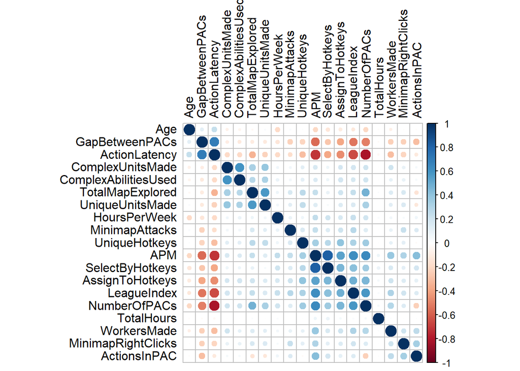

```r
df2_cor<-cor(training)

#png(filename="correlation_plot_large.png", width=1200, height=1200, res=120)
corrplot(df2_cor,method="circle",order="hclust",tl.col="black")
```

The correlation plot revealed striking relationships: ‘ActionLatency’ and ‘GapBetweenPACs’ exhibited a notable positive correlation, while ‘NumberOfPACs’ and ‘LeagueIndex’ inversely correlated with ‘ActionLatency.’ These early insights suggested key areas of focus for our predictive modeling.

### Initial Modeling

```r
#initial modeling
model <- lm(APM ~ ., data = training)

summary(model)
```

```
Call:
lm(formula = APM ~ ., data = training)

Residuals:
    Min      1Q  Median      3Q     Max
-74.204  -3.358   0.250   3.634  45.682

Coefficients:
                       Estimate Std. Error t value Pr(>|t|)
(Intercept)          -4.796e+01  2.684e+00 -17.872  < 2e-16 ***
LeagueIndex          -2.624e-01  1.482e-01  -1.770  0.07678 .
Age                  -1.020e-01  3.694e-02  -2.760  0.00583 **
HoursPerWeek         -7.170e-03  1.294e-02  -0.554  0.57960
TotalHours            6.433e-06  7.626e-06   0.844  0.39899
SelectByHotkeys       5.504e+03  3.702e+01 148.665  < 2e-16 ***
AssignToHotkeys      -1.178e+03  8.950e+02  -1.316  0.18827
UniqueHotkeys         8.659e-02  7.247e-02   1.195  0.23226
MinimapAttacks        3.001e+03  9.645e+02   3.112  0.00188 **
MinimapRightClicks    3.455e+03  4.582e+02   7.541 6.37e-14 ***
NumberOfPACs          2.396e+04  3.569e+02  67.128  < 2e-16 ***
GapBetweenPACs       -8.671e-03  1.317e-02  -0.659  0.51022
ActionLatency        -1.585e-01  1.786e-02  -8.874  < 2e-16 ***
ActionsInPAC          1.325e+01  1.446e-01  91.683  < 2e-16 ***
TotalMapExplored      2.797e-03  2.691e-02   0.104  0.91722
WorkersMade           2.427e+03  3.231e+02   7.512 7.90e-14 ***
UniqueUnitsMade      -2.208e-01  1.022e-01  -2.161  0.03079 *
ComplexUnitsMade      1.643e+03  1.783e+03   0.922  0.35672
ComplexAbilitiesUsed -3.199e+03  7.191e+02  -4.448 9.01e-06 ***
---
Signif. codes:  0 '***' 0.001 '**' 0.01 '*' 0.05 '.' 0.1 ' ' 1

Residual standard error: 7.59 on 2651 degrees of freedom
Multiple R-squared:  0.9756,    Adjusted R-squared:  0.9755
F-statistic:  5899 on 18 and 2651 DF,  p-value: < 2.2e-16
```

4 most significant features with p-value less then 2e-16

1. SelectByHotkeys
2. NumberOfPACs
3. ActionLatency
4. ActionInPAC

For the initial model, we included all available predictors. However, upon scrutinizing the model’s summary, we identified several predictors like ‘HoursPerWeek’, and ‘TotalHours’ that lacked statistical significance, hence presenting an opportunity to refine our model.

#### Predictive Capacity

```r
predictions <- predict(model, newdata = testing)

# Actual values
actuals <- testing$APM

# Compute errors
errors <- predictions - actuals
MAE <- mean(abs(errors))
MSE <- mean(errors^2)
RMSE <- sqrt(MSE)

# Print the metrics
cat("MAE:", MAE, "\nMSE:", MSE, "\nRMSE:", RMSE)
```

```
MAE: 5.528712
MSE: 87.58362
RMSE: 9.358612
```

### Model Improvement

#### Best Subset Selection

```r
regs<-regsubsets(APM~.,data=training)

regsummary<-summary(regs)
cp<-regsummary$cp
bic<-regsummary$bic
r2<-regsummary$adjr2

cp_min<-which.min(cp)
bic_min<-which.min(bic)
r2_min<-which.max(r2)


print("cp: ",cp_min)
```

```
[1] "cp: "
```

```r
print("bic: ",bic_min)
```

```
[1] "bic: "
```

```r
print("r_squared: ",r2_min)
```

```
[1] "r_squared: "
```

```r
coef(regs,id=cp_min)
```

```
         (Intercept)                  Age      SelectByHotkeys
       -5.029721e+01        -9.689564e-02         5.493420e+03
  MinimapRightClicks         NumberOfPACs        ActionLatency
        3.558490e+03         2.379958e+04        -1.575666e-01
        ActionsInPAC          WorkersMade ComplexAbilitiesUsed
        1.329361e+01         2.350571e+03        -3.326345e+03
```

```r
coef(regs,id=bic_min)
```

```
         (Intercept)      SelectByHotkeys   MinimapRightClicks
         -52.1641912         5497.8803883         3508.5806204
        NumberOfPACs        ActionLatency         ActionsInPAC
       23809.1317349           -0.1619293           13.2944260
         WorkersMade ComplexAbilitiesUsed
        2359.1640158        -3305.2425829
```

```r
coef(regs,id=r2_min)
```

```
         (Intercept)                  Age      SelectByHotkeys
       -5.029721e+01        -9.689564e-02         5.493420e+03
  MinimapRightClicks         NumberOfPACs        ActionLatency
        3.558490e+03         2.379958e+04        -1.575666e-01
        ActionsInPAC          WorkersMade ComplexAbilitiesUsed
        1.329361e+01         2.350571e+03        -3.326345e+03
```

significant features:

1. Age
2. SelectByHotkeys
3. MinimapRightClicks
4. NumberOfPACs
5. ActionLatency
6. ActionsInPAC
7. WorkersMade
8. ComplexAbilitiesUsed

#### Forward stepwise selection

```r
regs<-regsubsets(APM~.,data=training,method="forward")

regsummary<-summary(regs)
cp<-regsummary$cp
bic<-regsummary$bic
r2<-regsummary$adjr2

cp_min<-which.min(cp)
bic_min<-which.min(bic)
r2_min<-which.max(r2)

coef(regs,id=cp_min)
```

```
         (Intercept)                  Age      SelectByHotkeys
       -5.029721e+01        -9.689564e-02         5.493420e+03
  MinimapRightClicks         NumberOfPACs        ActionLatency
        3.558490e+03         2.379958e+04        -1.575666e-01
        ActionsInPAC          WorkersMade ComplexAbilitiesUsed
        1.329361e+01         2.350571e+03        -3.326345e+03
```

```r
coef(regs,id=bic_min)
```

```
         (Intercept)      SelectByHotkeys   MinimapRightClicks
         -52.1641912         5497.8803883         3508.5806204
        NumberOfPACs        ActionLatency         ActionsInPAC
       23809.1317349           -0.1619293           13.2944260
         WorkersMade ComplexAbilitiesUsed
        2359.1640158        -3305.2425829
```

```r
coef(regs,id=r2_min)
```

```
         (Intercept)                  Age      SelectByHotkeys
       -5.029721e+01        -9.689564e-02         5.493420e+03
  MinimapRightClicks         NumberOfPACs        ActionLatency
        3.558490e+03         2.379958e+04        -1.575666e-01
        ActionsInPAC          WorkersMade ComplexAbilitiesUsed
        1.329361e+01         2.350571e+03        -3.326345e+03
```

significant features:

1. Age
2. SelectByHotkeys
3. MinimapRightClicks
4. NumberOfPACs
5. ActionLatency
6. ActionsInPAC
7. WorkersMade
8. ComplexAbilitiesUsed

same as best subset selection

#### Backward stepwise selection

```r
regs<-regsubsets(APM~.,data=training,method="backward")

regsummary<-summary(regs)
cp<-regsummary$cp
bic<-regsummary$bic
r2<-regsummary$adjr2

cp_min<-which.min(cp)
bic_min<-which.min(bic)
r2_min<-which.max(r2)

coef(regs,id=cp_min)
```

```
         (Intercept)                  Age      SelectByHotkeys
       -5.029721e+01        -9.689564e-02         5.493420e+03
  MinimapRightClicks         NumberOfPACs        ActionLatency
        3.558490e+03         2.379958e+04        -1.575666e-01
        ActionsInPAC          WorkersMade ComplexAbilitiesUsed
        1.329361e+01         2.350571e+03        -3.326345e+03
```

```r
coef(regs,id=bic_min)
```

```
         (Intercept)      SelectByHotkeys   MinimapRightClicks
         -52.1641912         5497.8803883         3508.5806204
        NumberOfPACs        ActionLatency         ActionsInPAC
       23809.1317349           -0.1619293           13.2944260
         WorkersMade ComplexAbilitiesUsed
        2359.1640158        -3305.2425829
```

```r
coef(regs,id=r2_min)
```

```
         (Intercept)                  Age      SelectByHotkeys
       -5.029721e+01        -9.689564e-02         5.493420e+03
  MinimapRightClicks         NumberOfPACs        ActionLatency
        3.558490e+03         2.379958e+04        -1.575666e-01
        ActionsInPAC          WorkersMade ComplexAbilitiesUsed
        1.329361e+01         2.350571e+03        -3.326345e+03
```

### Optimal Linear Regression Model

```r
###process the data

training1<-training%>%
  select(-GapBetweenPACs,-LeagueIndex,-HoursPerWeek,-TotalHours,-AssignToHotkeys,-UniqueHotkeys,-GapBetweenPACs,-TotalMapExplored,-ComplexUnitsMade)
```

```r
best_fit<-lm(APM~.,data=training1)
pred<-predict(best_fit,newdata=testing)
real<-testing$APM

errors <- pred-real
MAE <- mean(abs(errors))
MSE <- mean(errors^2)
RMSE <- sqrt(MSE)

cat("MAE:", MAE, "\nMSE:", MSE, "\nRMSE:", RMSE)
```

```
MAE: 5.530872
MSE: 87.56293
RMSE: 9.357507
```

```r
summary(best_fit)
```

```
Call:
lm(formula = APM ~ ., data = training1)

Residuals:
    Min      1Q  Median      3Q     Max
-74.657  -3.332   0.266   3.622  45.635

Coefficients:
                       Estimate Std. Error t value Pr(>|t|)
(Intercept)          -4.947e+01  2.593e+00 -19.074  < 2e-16 ***
Age                  -9.800e-02  3.621e-02  -2.706  0.00685 **
SelectByHotkeys       5.483e+03  3.444e+01 159.196  < 2e-16 ***
MinimapAttacks        2.647e+03  9.350e+02   2.831  0.00467 **
MinimapRightClicks    3.477e+03  4.562e+02   7.621 3.48e-14 ***
NumberOfPACs          2.386e+04  3.414e+02  69.899  < 2e-16 ***
ActionLatency        -1.554e-01  1.590e-02  -9.772  < 2e-16 ***
ActionsInPAC          1.324e+01  1.387e-01  95.475  < 2e-16 ***
WorkersMade           2.389e+03  3.173e+02   7.529 6.98e-14 ***
UniqueUnitsMade      -1.752e-01  8.867e-02  -1.975  0.04833 *
ComplexAbilitiesUsed -3.009e+03  6.044e+02  -4.979 6.79e-07 ***
---
Signif. codes:  0 '***' 0.001 '**' 0.01 '*' 0.05 '.' 0.1 ' ' 1

Residual standard error: 7.591 on 2659 degrees of freedom
Multiple R-squared:  0.9756,    Adjusted R-squared:  0.9755
F-statistic: 1.062e+04 on 10 and 2659 DF,  p-value: < 2.2e-16
```

## Conclusion

Considering the scale of APM, the predictive metric RMSE at around 9.357 means that linear regression model may not be the optimal choice for predicting player’s APM.

The most important features in predicting a player’s APM include:

1. Age
2. SelectByHotkeys
3. MinimapRightClicks
4. NumberOfPACs
5. ActionLatency
6. ActionsInPAC
7. WorkersMade
8. ComplexAbilitiesUsed

```r
summary(df$APM)
```

```
   Min. 1st Qu.  Median    Mean 3rd Qu.    Max.
  22.06   79.23  107.07  114.58  140.16  389.83
```